# Attended vs unattended systolic blood pressure measurement: A randomized comparison in patients with cardiovascular disease - Keeley - 2020 - The Journal of Clinical Hypertension - Wiley Online Librar

[The Journal of Clinical Hypertension](https://onlinelibrary.wiley.com/journal/17517176)

[Volume 22, Issue 11](https://onlinelibrary.wiley.com/toc/17517176/2020/22/11) p. 1987-1992

ORIGINAL PAPER

Free Access

# Attended vs unattended systolic blood pressure measurement: A randomized comparison in patients with cardiovascular disease

[Ellen C. Keeley MD, MS](https://onlinelibrary.wiley.com/action/doSearch?ContribAuthorRaw=Keeley%2C+Ellen+C),

[Matthew Villanueva BS](https://onlinelibrary.wiley.com/action/doSearch?ContribAuthorRaw=Villanueva%2C+Matthew),

[Yiqing E. Chen MS](https://onlinelibrary.wiley.com/action/doSearch?ContribAuthorRaw=Chen%2C+Yiqing+E),

[Yan Gong PhD](https://onlinelibrary.wiley.com/action/doSearch?ContribAuthorRaw=Gong%2C+Yan),

[Eileen M. Handberg PhD](https://onlinelibrary.wiley.com/action/doSearch?ContribAuthorRaw=Handberg%2C+Eileen+M),

[Steven M. Smith PharmD, MPH](https://onlinelibrary.wiley.com/action/doSearch?ContribAuthorRaw=Smith%2C+Steven+M),

[Carl J. Pepine MD](https://onlinelibrary.wiley.com/action/doSearch?ContribAuthorRaw=Pepine%2C+Carl+J),

… See all authors

First published: 20 September 2020

https://doi.org/10.1111/jch.14037

## Abstract

Recent clinical guidelines recommend lower blood pressure (BP) goals for most patients, and recent trends have favored use of automated unattended BP measurements in the office setting to minimize observer error and white-coat effects. Patients attending a routinely scheduled CVD clinic visit were prospectively randomized to BP measured using an attended, followed by an unattended method, or vice versa, after a controlled rest period. All study BP measurements were obtained in triplicate using the automated Omron HEM-907XL BP monitor, and averaged. The outcome was difference in SBP. Routinely measured clinic BP from the same visit was extracted from the medical record, and compared with attended and unattended BP. A total of 102 patients were randomized, and mean age was 63 years, 52% female and 75% Caucasian. Attended and unattended SBP was 125.4 ± 20.4 and 122.6 ± 21.0 mm Hg, mean ± SD, respectively. Routine clinic SBP was 130.6 ± 23.6 mm Hg. Attended SBP was 2.7 mm Hg higher than the unattended measurement (95% CI 1.3-4.1; *P* = .0002). Routine clinic SBP was 5.2 mm Hg higher than attended SBP (95% CI 2.4-8.0; *P* = .0003) and 8.0 mm Hg higher than unattended SBP (95% CI 5.4-10.5; *P* < .0001). Attended measurement of BP is significantly higher than unattended measurement and the difference is physiologically meaningful, even in a CVD cohort with generally well-controlled hypertension. Furthermore, routine clinic SBP substantially overestimates both attended and unattended automated SBP, with important implications for treatment decisions like dose and/or drug escalation.

## 1 INTRODUCTION

Hypertension affects over 50% of all US adults in their lifetime<sup>1</sup> and is the most prevalent modifiable attributable risk for adverse outcomes. Given that recent clinical guidelines recommend lower blood pressure (BP) goals for most patients, contemporary trends favor use of automated unattended BP measurements in the office setting to minimize observer error and white-coat effects and help clinicians balance the long-term cardiovascular (CV) benefits of more stringent BP control with the increased risk for adverse events resulting from more intensive antihypertensive therapies (eg, electrolyte abnormalities, syncope/falls, acute kidney injury).<sup>1, 2</sup> However, accuracy of BP measurement is greatly influenced by numerous factors, most of which are related to the technique employed during measurement. One factor, which has garnered increased interest in recent years, is whether BP measurement is attended (health care worker in the room during BP ascertainment) or unattended (health care worker absent during BP ascertainment).<sup>3</sup> The Systolic Blood Pressure Intervention Trial (SPRINT) brought this issue into sharp focus following controversy over inconsistent BP measurement techniques, namely, that approximately half of SPRINT study sites performed attended BP measurements, whereas the remainder performed unattended BP measurements.<sup>4</sup> Unattended and automated BP measurement may yield lower BP measurements by minimizing the “white-coat effect” and avoid observer errors. Previous studies also suggest that unattended automated BP measurements are more consistent across clinic visits and do not differ from ambulatory BP, which has shown to be a better predictor of cardiovascular risk than conventional BP.<sup>5, 6</sup> However, most US clinical practice settings and nearly all prior landmark hypertension studies used attended BP measurement. Nevertheless, few studies have prospectively assessed whether attended or unattended automatic BP measurements are different among patients with cardiovascular disease (CVD), in whom risk for adverse cardiovascular outcomes is greatest. Therefore, the goal of this study was to evaluate prospectively the extent to which attendance versus non-attendance of BP measurement influences automated BP measurements among patients with CVD.

## 2 METHODS

This randomized clinical study was approved by the University of Florida Institutional Review Board, and all study participants provided voluntary written informed consent prior to being enrolled. Patients 18 years of age or older being seen for a routine clinical visit at a single cardiovascular clinic at the University of Florida were eligible to participate. Exclusion criteria were (1) presence of a dialysis fistula in both arms, (2) history of bilateral mastectomy, or (3) inability or unwillingness to provide informed consent. Patients were randomly assigned in a 1:1 ratio to (1) unattended BP measurement, followed by attended BP measurement, or (2) attended BP measurement followed by unattended BP measurement. Randomization was used to control for any effect that the order of measurements could have on observed differences between the two measurement techniques. Blinding was not feasible and, as such, was not used in our study. Attended measurement was defined as the presence of a study staff member during BP measurement. Unattended measurement was defined as having the participant alone in the clinic room for the entire duration of BP measurement.

### 2.1 Blood pressure measurement

The procedure was explained in detail, and then, all patients were given 5 minutes of unattended quiet rest in a sitting position before BP measurements were obtained for both attended and unattended measurements. In both measurement scenarios, the automated Omron HEM-907XL BP monitor (Omron Healthcare, Lake Forest, IL, USA) was programmed to record three readings at 1-minute intervals. The average of the readings was recorded and used for statistical analysis. For unattended BP measurements, the staff activated the device and then left the room. The staff member did not return until the 5-minute rest period and the three BP reading had been completed. For attended BP measurements, the study staff allowed for a 5-minute rest period and then entered the room to place the BP cuff and remained in the room while the readings were obtained. There was approximately a 5-minute interval between the two measurements. All BP measurements were taken with the patient sitting upright in a chair, both feet flat on the floor and the appropriately sized BP cuff placed on the non-dominant arm maintained at the level of the heart. Neither the patient nor the study staff member spoke while measurements were being taken. As part of standard clinical care, a single automated clinic BP was also measured for each patient by a medical assistant in the clinic according to the routine clinic procedure, within 10-15 minutes of the patient arriving at the clinic and being taken to an examination room. This clinic BP measurement was obtained prior to informed consent and randomization, per usual clinic procedure using an automated BP monitor (Welch Allyn model 123866), and was extracted from the electronic medical record for comparison to the attended and unattended measurements. This measurement will hereafter be referred to as the routine clinic BP. Of note, the medical assistant performing the clinic BP measurement was unaware of which patients were considered for inclusion in the study.

Baseline demographic information was collected from the patient supplemented by their electronic health record, including age, race, ethnicity, sex, height, weight, medical comorbidities, number/dose of specific antihypertensive medications, and other relevant medications. In addition, subjects were asked to provide information about when they last took their antihypertensive medication(s), as well as information regarding recent caffeine consumption and tobacco use. Specific comorbidities collected included diabetes mellitus, hypertension, hyperlipidemia, renal insufficiency, coronary artery disease, congestive heart failure, and recent acute myocardial infarction (within 3 months).

### 2.2 Statistical analysis

The primary outcome of interest was the difference between study SBP measurements (attended versus unattended) in each patient. Secondary outcomes included differences between the routine clinic SBP and each study BP measurement. The two randomization groups were combined to increase the power of the analysis after comparisons indicated there were no statistically significant measurement order effects. Pairwise comparisons between routine clinic, attended, and unattended SBP were performed using paired *t* test. Pearson correlation was performed to evaluate the correlation between routine clinic, attended, and unattended SBP. All statistical analyses were done using SAS version 9.4 (SAS Institute Inc., Cary, NC). Statistical significance was set at a *P* value of .05.

## 3 RESULTS

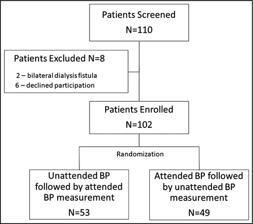

**Figure 1**

Flow diagram of patients screened and enrolled in the study, including number of patients screened, reasons for screen failure, and numbers of patients randomized to each group

Table 1. Pertinent demographic and clinical characteristics of the study population

[output not shown]

### Note

- Values expressed as mean ± standard deviation or number (percentage).
- * *P* value is comparison of randomized groups

Among all patients, mean attended, unattended, and clinical SBP was 125.4 ± 20.4, 122.6 ± 21.0, and 130.6 ± 23.6 mm Hg, respectively, as summarized in Table 2. Attended SBP was 2.7 mm Hg higher than the unattended measurement (95% CI 1.3-4.1; *P* = .0002). When considering only patients with a recent myocardial infarction, who are among the highest risk patients, a similar difference in SBP was observed, with attended measurement being 2.8 mm Hg higher (95% CI 0.6-5.0; *P* = .0132).

Table 2. Average unattended, attended, and clinic systolic blood pressure values

| Characteristic | Total Population (N = 102) | Unattended Measurement First (N = 53) | Attended Measurement First (N = 49) | *P* Value* |
| --- | --- | --- | --- | --- |
| Attended SBP | 125.4 ± 20.4 | 123.9 ± 20.4 | 127.0 ± 20.6 | .45 |
| Unattended SBP | 122.6 ± 21.0 | 119.8 ± 19.1 | 125.7 ± 22.7 | .16 |
| Routine clinic SBP | 130.6 ± 23.6 | 127.4 ± 22.9 | 134.0 ± 24.0 | .16 |

### Note

- Data represent blood pressure (in mm Hg) mean ± standard deviation. SBP, systolic blood pressure.
- * *P* value is comparison of randomized groups

Larger differences were observed when comparing attended and unattended measurements with the routine clinic SBP. The average routine clinic SBP was 130.6 ± 23.6 mm Hg. On average, the routine clinic SBP was 5.2 mm Hg higher than the attended SBP (95% CI 2.4-8.0; *P* = .0003) and 8.0 mm Hg higher than the unattended SBP (95% CI 5.4-10.5; *P* < .0001). Scatter plots and correlation coefficients for the pairwise SBP readings according to measurement technique are presented in Figure 2A–C. While unattended and attended SBP are very closely correlated (Pearson *r* = .94, Figure 2A), clinic SBP has a lower correlation with both attended and unattended SBP (Pearson *r* = 0.81, Figure 2B and Pearson *r* = 0.83, Figure 2C, respectively).

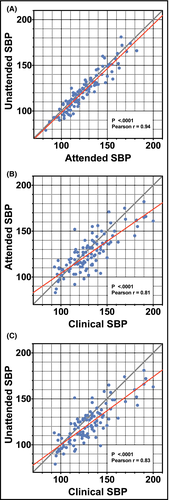

**Figure 2**

Correlations between unattended, attended, and clinic SBP. (A) Shows correlation between attended and unattended SBP measurements. (B) Shows correlation between attended SPB and clinic SBP. (C) Shows correlation between unattended SBP and clinic SBP. In each graph, the dots represent each patient, the gray line indicates perfect correlation, and the red line indicates the line of best fit

## 4 DISCUSSION

We observed among a cohort of patients evaluated in a CVD ambulatory clinic, measuring BP in an unattended approach is associated with a lower SBP compared with an attended approach, and this difference is physiologically meaningful. Additionally, we observed even larger differences when the attended or unattended SBP was compared with the routine clinic SBP. Previous studies have shown that the attended SBP is approximately 15 mm Hg higher than the unattended SBP; however, many of these studies compared measurements obtained via manual auscultation using a stethoscope versus those obtained via an automated BP monitor.<sup>7, 8</sup> This type of comparison may not truly isolate the effect of attendance alone since manual auscultatory BP can be subject to inaccuracies not observed with automatic BP, such as fast cuff deflation, observer bias like digit rounding, observer hearing deficit, and use of stethoscope bell vs. diaphragm.<sup>9</sup> Additionally, our findings differ from a previous observational study that found automated attended and unattended measurements to be very similar.<sup>10</sup>

Our results demonstrate that attendance by study staff or clinic staff during BP measurements is associated with elevation of BP, presumably due to the “white-coat effect,”<sup>7</sup> an effect believed to be triggered by a sympathetic nervous system reaction to being in a doctor's office.<sup>11</sup> However, among the CVD patients in our study population, with many having very well-controlled HTN with systolic BPs in the 120s, we did not observe large differences comparing attended and unattended BP. We observed lower average SBP likely because the majority of our CVD population was receiving at least two antihypertensive medications and treated to lower BP targets based on current guideline recommendations,<sup>1</sup> and it may be because the white-coat effect is less pronounced at lower BPs. Some data suggest that among patients with a mean office SBP < 130 mm Hg regardless of treatment status, white-coat hypertension is generally minimized, with automatic office BP actually lower than awake ambulatory BP.<sup>10, 12</sup> Others have shown a similar relationship with increasing discrepancy in attended and unattended SBP at higher SBP levels.<sup>13</sup> An additional consideration is that our study took place in a cardiovascular specialty clinic rather than a primary care clinic. Most studies reporting the impact of white-coat effect are conducted in the primary care setting. Thus, it is plausible that this study being conducted in a specialty clinic setting where patient wait times may be less than in primary care clinics, contributed to a less pronounced white-coat effect in our study compared to previously reported data.

While our results demonstrate a BP difference based on clinician attendance, little is known about the difference in prognostic significance between the two techniques. Unattended BP presents several advantages over attended BP such as mitigation of the white-coat effect and conversation during measurement; however, much of what is known about the relationship between BP and CVD comes from studies using attended measurements. Conversely, data suggest that measurement of BP in both an attended and unattended manner is similarly correlated with preclinical organ damage, including left ventricular hypertrophy and carotid intima-media thickness.<sup>14</sup> Our results contribute information on the clinical utility of the unattended measurement of BP, a technique that has garnered more attention in recent clinical guidelines.<sup>15</sup>

The differences between the attended/unattended measurements and the routine clinic BP highlight the importance of the timing of BP measurement given that the routine clinic BP was performed soon after patient arrival, within 10-15 minutes in most cases, and prior to enrollment in the study. Additionally, many factors can affect the accuracy of BP readings taken at the beginning of a visit such as insufficient rest time, recent smoking, and caffeine consumption. According to a recently published scientific statement on BP measurement, insufficient rest time prior to measurement alone can result in a 4.2-11.6 mm Hg elevation in BP.<sup>9</sup> Moreover, a study comparing consecutive automatic office BP measurements (over 30 minutes) to daytime ambulatory BP demonstrated that BP declines substantially in the first fifteen minutes of a clinic visit before reaching a plateau.<sup>16</sup> Thus, the difference between attended/unattended measurements and the routine clinic BP in our study confirms the notion that BP taken at the beginning of a clinic visit is not comparable to measurements taken after longer periods of rest.

Our study has several limitations. Although there was no statistically significant difference in BP readings between randomized groups, it is possible that the sequential order of BP measurements may have impacted our results, with cumulative rest periods possibly contributing to lower BP readings. This may have been avoided if the study BP measurements were obtained on different days. Similarly, the estimated 15 minutes that elapsed between the clinic (routine) BP reading and the third (AOBP) reading could have exaggerated the difference between these two readings and should be considered when interpreting comparisons using the routine clinic BP. It is also worth noting that the definition of attended BP measurement used in our study differs slightly from the definition used in SPRINT. For attended measurements in SPRINT, study staff applied the BP cuff and programmed the device to delay measurement for 5 minutes (to allow for unattended rest), then entered the room while the device recorded. However, for attended measurements in our study, staff entered the room after a 5-minute unattended rest period to apply and activate the cuff while remaining in the room during measurement. Thus, it is plausible that the act of entering a room to apply a BP cuff and activate the device could have stimulated patients in this study, resulting in relatively higher attended BP values. Lastly, given that the routine clinic BP was taken prior to randomization, exact data on wait time or other factors that may affect BP were not recorded.

In conclusion, our findings suggest that among patients with CVD receiving care in a cardiovascular clinic, whether or not an observer is in the room with the patient during BP measurement has a direct, physiologically meaningful impact on BP. However, this difference appears to be smaller for patients with BP in the target range. Our routinely measured clinic BP was higher than attended or unattended readings, confirming the notion that initial BP measurements taken as part of standard clinic procedure are likely subject to the timing of measurements yielding higher readings. As such, a falsely elevated reading may prompt a clinician to initiate or intensify therapy for patients with BP above treatment goals, regardless of whether the additional therapy is truly warranted based on an accurately obtained BP measurement.

## CONFLICT OF INTEREST

None.

## **AUTHOR** **CONTRIBUTION**

Cooper-DeHoff, Pepine, Keeley, and Smith conceived the study. Villanueva, Keeley, Handberg, and Cooper-DeHoff conducted the study. Chen and Gong analyzed the data. Cooper-DeHoff, Keeley, Cooper-DeHoff, Villanueva, Chen, Gong, Smith, and Handberg interpreted the data. Villanueva, Keeley, Cooper-DeHoff, and Smith wrote the manuscript. Chen, Handberg, and Pepine critically reviewed the manuscript. All authors agree to be accountable for all aspects of the work, provided final approval of this work to be published, and had substantial contribution to this work.

[figure not shown]

[Volume22, Issue11](https://onlinelibrary.wiley.com/toc/17517176/2020/22/11)

November 2020

Pages 1987-1992

[figure not shown]